# Introduction to Regression in R

# Regresión Lineal Simple

Los modelos de regresión son una clase de modelos estadísticos que le permiten explorar la relación entre una variable de respuesta y algunas variables explicativas. Es decir, dadas algunas variables explicativas, puede hacer predicciones sobre el valor de la variable respuesta. La variable de respuesta, sobre la que desea hacer predicciones, también se conoce como variable dependiente. Estos dos términos son completamente intercambiables. Las variables explicativas, que se utilizan para explicar cómo cambiarán las predicciones, también se conocen como variables independientes.

La regresión lineal se utiliza cuando la variable de respuesta es numérica, mientras que la regresión logística se utiliza cuando la variable de respuesta es lógica, es decir, toma valores verdaderos o falsos.

Al gráfico de dispersión se le puede agregar una línea de tendencia, es decir, ajustar una línea que sigue los puntos de datos. En `ggplot`, las líneas de tendencia se agregan usando `geom_smooth()`. Al establecer el argumento del método en `lm`, para un “modelo lineal”, se obtiene una línea con tendencia calculada con una regresión lineal. La función `geom_smooth()` muestra una cinta de error estandar, que en este caso se desactivará.

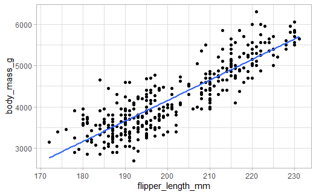

```r
ggplot(penguins, aes(flipper_length_mm, body_mass_g)) + geom_point() + geom_smooth(method = "lm", se = FALSE) + theme_light()
```

## Ajustando una regresión lineal

Una característica importante de la regresión lineal es que, las líneas de tendencia en los gráficos, son líneas rectas. Las líneas rectas están definidas por dos propiedades. El intercepto es el valor de *y* cuando *x* es cero, la pendiente o en inglés, *“slope”*, es la inclinación de la línea, igual a la cantidad que *y* aumenta si *x* aumenta en uno.

La ecuación para una línea recta es:

$y = intercepto + pendiente \cdot x$

Para ejecutar un modelo de regresión lineal, se llama a la función `lm` con dos argumentos. El primero es una fórmula, la variable respuesta se escribe del lado izquierdo de la virgulilla **(~)** y la variable explicativa del lado derecho; el segundo argumento, son los datos de los cuales se está importando la información.

```r
#El primer argumento que se imprime es el intercepto
# y el segundo es la pendiente
lm(body_mass_g~flipper_length_mm, data = penguins)
```

```
Call:
lm(formula = body_mass_g ~ flipper_length_mm, data = penguins)

Coefficients:
      (Intercept)  flipper_length_mm
         -5780.83              49.69
```

## Regresión con variables categóricas

Pa visualizar datos en los que se contienen variables categóricas es mejor adaptar con la función `facet_wrap()` la división según su categoría, como se muestra en el siguiente chunk.

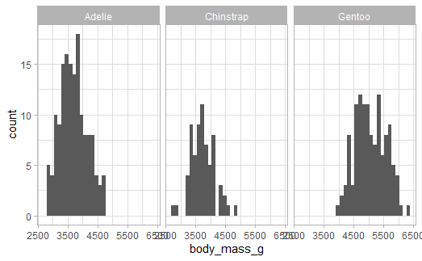

```r
ggplot(penguins, aes(body_mass_g)) + geom_histogram() + facet_wrap(vars(species)) + theme_light()
```

Al aplicar la regresión lineal

```r
lm(body_mass_g ~ species, data = penguins)
```

```
Call:
lm(formula = body_mass_g ~ species, data = penguins)

Coefficients:
     (Intercept)  speciesChinstrap     speciesGentoo
         3700.66             32.43           1375.35
```

```r
# Podemos notar que nos falta una variable categórica, esto se resuelve agregando un 0
lm(body_mass_g ~ species + 0, data = penguins)
```

```
Call:
lm(formula = body_mass_g ~ species + 0, data = penguins)

Coefficients:
   speciesAdelie  speciesChinstrap     speciesGentoo
            3701              3733              5076
```

# Predicciones y modelos

Antes de hacer predicciones, necesitamos un modelo. El principio detrás de la predicción es hacer preguntas de la forma “si establezco las variables explicativas de estos valores, ¿qué valor tendría la variable de respuesta?”, eso significa que el siguiente paso es elegir algunos valores para las variables explicativas.

```r
#Ahora utilizamos la función `predict`
predict(modelo, explanatory_data)
```

```
       1        2        3        4        5        6        7        8
3162.571 3212.256 3261.942 3311.627 3361.313 3410.998 3460.684 3510.370
       9       10       11       12       13       14       15       16
3560.055 3609.741 3659.426 3709.112 3758.797 3808.483 3858.169 3907.854
      17       18       19       20       21       22       23       24
3957.540 4007.225 4056.911 4106.596 4156.282 4205.967 4255.653 4305.339
      25       26       27       28       29       30       31
4355.024 4404.710 4454.395 4504.081 4553.766 4603.452 4653.138
```

La función `predict()` devuelve un vector de predicciones, una para cada fila de los datos explicativos, pero no es muy útil tener esta función para programar, es más fácil trabajar con las predicciones si están en un `data.frame` junto con las variables explicativas.

```r
prediction_data <- explanatory_data %>%
  mutate(body_mass_g = predict(
    modelo, explanatory_data
  ))
prediction_data
```

| flipper_length_mm | body_mass_g |
| --- | --- |
| 180 | 3162.571 |
| 181 | 3212.256 |
| 182 | 3261.942 |
| 183 | 3311.627 |
| 184 | 3361.313 |
| 185 | 3410.998 |
| 186 | 3460.684 |
| 187 | 3510.370 |
| 188 | 3560.055 |
| 189 | 3609.741 |

[output cut: 21 more lines]

Así, podemos ver las predicciones de la masa corporal, según sea la longitud de la aleta. Ahora agregamos estas predicciones a la gráfica y podremos notar que las predicciones se encuentran exactamente en la línea de tendencia.

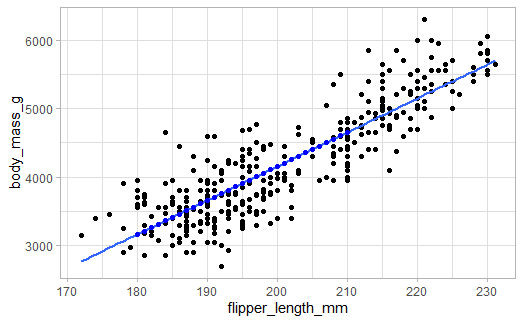

```r
ggplot(penguins, aes(flipper_length_mm, body_mass_g)) +
  geom_point() +
  geom_smooth(method = "lm", se = FALSE) +
  geom_point(
    data = prediction_data,
    color = "blue"
  ) + theme_light()
```

El modelo lineal nos permite hacer predicciones fuera del rango de los datos observados, a esto se le llama *extrapolación.* La extrapolación a veces es apropiada, pero puede dar lugar a resultados engañosos o ridículos. Por esto, se debe observar los datos y saber qué se está prediciendo.

## Elementos del modelo

`coefficients`: es una función que devuelve el vector numérico de coeficientes con sus respectivos nombres

`fitted`: es la función para las predicciones en el conjunto de datos original utilizado para crear el modelo, esta devuelve un vector numérico de los valores ajustados del modelo

`predict`: es una función que se encarga de hacer lo mismo que `fitted`, a diferencia de que a la función `predict` toma dos valores, el primero es el modelo y el segundo la variable explicativa

`residuals`: son una medida de ineactitud en el ajuste del modelo, cada residuo le corresponde a cada uno del conjunto de datos. Cada residuo es el valor de respuesta real menos el valor de respuesta previsto (la predicción)

`summary`: muestra una impresión más extendida de los detalles del modelo

`tidy`: En la paquetería `broom` proporciona funciones que devuelven *data frames* para que sea más sencillo trabajar con estos datos. La función `tidy` devuelve los detalles del coeficiente en un *data frame*.

`augment`: devuelve los resultados del nivel de obervación, cada columna es un argumento que se utilizó para crear el modelo. [`broom`]

`glance`: devuelve los resultados a nivel de modelo, son las métricas que se observaron en el `summary` y algunas otras. [`broom`]

**Importante:** si el modelo tiene un buen ajuste, los *residuos* deben seguir una distribución normal.

```r
coefficients(modelo)
fitted(modelo)
residuals(modelo)
summary(modelo)
```

[output not shown]

Ahora, de la paquetería `broom`, donde se almacenan los datos en un *data frame*.

```r
tidy(modelo)
```

| term | estimate | std.error | statistic | p.value |
| --- | --- | --- | --- | --- |
| (Intercept) | -5780.83136 | 305.814504 | -18.90306 | 5.587301e-55 |
| flipper_length_mm | 49.68557 | 1.518404 | 32.72223 | 4.370681e-107 |

```r
augment(modelo)
```

| .rownames | body_mass_g | flipper_length_mm | .fitted | .resid | .hat | .sigma | .cooksd | .std.resid |
| --- | --- | --- | --- | --- | --- | --- | --- | --- |
| 1 | 3750 | 181 | 3212.256 | 5.377438e+02 | 0.008806161 | 393.7680 | 8.336521e-03 | 1.369914e+00 |
| 2 | 3800 | 186 | 3460.684 | 3.393160e+02 | 0.006223320 | 394.4263 | 2.333554e-03 | 8.632910e-01 |
| 3 | 3250 | 195 | 3907.854 | -6.578541e+02 | 0.003442906 | 393.2338 | 4.825525e-03 | -1.671382e+00 |
| 5 | 3450 | 193 | 3808.483 | -3.584830e+02 | 0.003853143 | 394.3771 | 1.604981e-03 | -9.109700e-01 |
| 6 | 3650 | 190 | 3659.426 | -9.426259e+00 | 0.004690962 | 394.8589 | 1.353285e-06 | -2.396391e-02 |
| 7 | 3625 | 181 | 3212.256 | 4.127438e+02 | 0.008806161 | 394.2168 | 4.911285e-03 | 1.051474e+00 |
| 8 | 4675 | 195 | 3907.854 | 7.671459e+02 | 0.003442906 | 392.6472 | 6.562077e-03 | 1.949055e+00 |
| 9 | 3475 | 193 | 3808.483 | -3.334830e+02 | 0.003853143 | 394.4420 | 1.388929e-03 | -8.474405e-01 |
| 10 | 4250 | 190 | 3659.426 | 5.905737e+02 | 0.004690962 | 393.5482 | 5.312009e-03 | 1.501386e+00 |
| 11 | 3300 | 186 | 3460.684 | -1.606840e+02 | 0.006223320 | 394.7622 | 5.233043e-04 | -4.088137e-01 |

[output cut: 332 more lines]

```r
glance(modelo)
```

| r.squared | adj.r.squared | sigma | statistic | p.value | df | logLik | AIC | BIC | deviance | df.residual | nobs |
| --- | --- | --- | --- | --- | --- | --- | --- | --- | --- | --- | --- |
| 0.7589925 | 0.7582837 | 394.2782 | 1070.745 | 4.370681e-107 | 1 | -2528.427 | 5062.855 | 5074.359 | 52854796 | 340 | 342 |

## Regresión a la medida

LA regresión a la medida es una propiedad de los datos, no un tipo de modelo, sino la regresión lineal se pueden utilizar para cuantificar su efecto. Si revisamos el concepto en forma de ecuación es: *valor respuesta = valor ajustado + residual*.

Los residuales pueden existir por dos posibilidades, la primera podría deberse a que el modelo no es el mejor, sin embargo, normalmente no es posible o deseable tener un modelo perfecto, porque el mundo contiene mucha aleatoriedad y el modelo no debe capturar eso, por esto, la segunda posibilidad es la aeatoriedad.